# Return Home

[View Code on Github](https://github.com/JohnKimaiyo/Business-Analytics-Power-BI/blob/main/Projects/Webscraping%20Projects/Top%20Male%20RnB%20Music%20Artist%20YouTube%20Channels.ipynb)

# Top Male RnB Music Artist YouTube Channels EDA

## 1 Babyface

Kenneth Brian Edmonds, better known by his stage name Babyface, is an American singer, songwriter, and record producer. He has written and produced over 26 number-one R&B hits throughout his career and has won 12 Grammy Awards. He was ranked number 20 on NME's 50 of The Greatest Producers Ever list

## 2 Luther Vandros

Luther Ronzoni Vandross Jr. was an American soul and R&B singer, songwriter, and record producer. Throughout his career, he achieved eleven consecutive RIAA-certified platinum albums and sold over 40 million records

## 3 T Pain

Faheem Rashad Najm, better known by his stage name T-Pain, is an American singer, songwriter, and record producer. He is known for popularizing creative use of the Auto-Tune pitch correction effect, used with extreme parameter settings to create distinctive vocal sounds.

## 5 Neyo

Shaffer Chimere Smith, known professionally as Ne-Yo, is an American R&B singer, songwriter, actor, dancer, and record producer. Regarded as a leading figure of 2000s R&B music, he is the recipient of numerous accolades including three Grammy Awards

## 6 Joe

```python
# lets import libraries
from googleapiclient.discovery import build
import pandas as pd
import seaborn as sns
import matplotlib.pyplot as plt
```

## 1 Babyface

```python
#  Function to get   Babyface Youtube channel statistics

api_key = 'AIzaSyB24Kop04L1GlTgRCm1XtQ4KB2a4gaBOwA'
Babyface_channel_id = ['UCoa4gRP6_5CMEzt_9QyEmLg' #  Babyface

              ]
youtube = build('youtube','v3',developerKey = api_key)

from googleapiclient.errors import HttpError

def get_channel_stats(youtube, Babyface_channel_id):
    all_data = []
    try:
        request = youtube.channels().list(
            part='snippet,contentDetails,statistics',
            id=','.join(Babyface_channel_id)
        )
        response = request.execute()

        for item in response.get('items', []):
            snippet = item.get('snippet', {})
            statistics = item.get('statistics', {})

            data = {
                'Channel_name': snippet.get('title', ''),
                'Subscribers': statistics.get('subscriberCount', ''),
                'Views': statistics.get('viewCount', ''),
                'Total_videos': statistics.get('videoCount', '')
            }

            all_data.append(data)

    except HttpError as e:
        print(f"HTTP error occurred: {e}")
        print(f"Request URL: {e.resp.request.url}")
        print(f"Request body: {e.resp.request.body}")

    return all_data
```

```python
get_channel_stats(youtube,Babyface_channel_id)
```

```
[{'Channel_name': 'Babyface',
  'Subscribers': '431000',
  'Views': '321151674',
  'Total_videos': '18'}]
```

```python
channel_statistics = get_channel_stats(youtube,Babyface_channel_id )
```

```python
Babyface_channel_data =pd.DataFrame(channel_statistics)
```

```python
Babyface_channel_data
```

|  | Channel_name | Subscribers | Views | Total_videos |
| --- | --- | --- | --- | --- |
| 0 | Babyface | 431000 | 321151674 | 18 |

## 2 Luther Vandros

```python
#  Function to get Luther Vandros  in Youtube channel statistics

api_key = 'AIzaSyB24Kop04L1GlTgRCm1XtQ4KB2a4gaBOwA'
Luther_Vandros_channel_id = ['UC3sbjt9jIZc1W3wfVlYbG8Q' # Luther Vandros

              ]
youtube = build('youtube','v3',developerKey = api_key)



def get_channel_stats(youtube, Luther_Vandros_channel_id):
    all_data = []
    try:
        request = youtube.channels().list(
            part='snippet,contentDetails,statistics',
            id=','.join(Luther_Vandros_channel_id)
        )
        response = request.execute()

        for item in response.get('items', []):
            snippet = item.get('snippet', {})
            statistics = item.get('statistics', {})

            data = {
                'Channel_name': snippet.get('title', ''),
                'Subscribers': statistics.get('subscriberCount', ''),
                'Views': statistics.get('viewCount', ''),
                'Total_videos': statistics.get('videoCount', '')
            }

            all_data.append(data)

    except HttpError as e:
        print(f"HTTP error occurred: {e}")
        print(f"Request URL: {e.resp.request.url}")
        print(f"Request body: {e.resp.request.body}")

    return all_data
```

```python
get_channel_stats(youtube,Luther_Vandros_channel_id)
```

```
[{'Channel_name': 'Luther Vandross',
  'Subscribers': '1370000',
  'Views': '1050679871',
  'Total_videos': '7'}]
```

```python
channel_statistics = get_channel_stats(youtube,Luther_Vandros_channel_id)
```

```python
Luther_Vandros_channel_data =pd.DataFrame(channel_statistics)
```

```python
Luther_Vandros_channel_data
```

|  | Channel_name | Subscribers | Views | Total_videos |
| --- | --- | --- | --- | --- |
| 0 | Luther Vandross | 1370000 | 1050679871 | 7 |

## 3 T Pain

```python
#  Function to get T Pain  in Youtube channel statistics

api_key = 'AIzaSyB24Kop04L1GlTgRCm1XtQ4KB2a4gaBOwA'
T_Pain_channel_id = ['UCwff7OoSHp3el6GqnSwcSdA' # T Pain

              ]
youtube = build('youtube','v3',developerKey = api_key)



def get_channel_stats(youtube, T_Pain_channel_id):
    all_data = []
    try:
        request = youtube.channels().list(
            part='snippet,contentDetails,statistics',
            id=','.join(T_Pain_channel_id)
        )
        response = request.execute()

        for item in response.get('items', []):
            snippet = item.get('snippet', {})
            statistics = item.get('statistics', {})

            data = {
                'Channel_name': snippet.get('title', ''),
                'Subscribers': statistics.get('subscriberCount', ''),
                'Views': statistics.get('viewCount', ''),
                'Total_videos': statistics.get('videoCount', '')
            }

            all_data.append(data)

    except HttpError as e:
        print(f"HTTP error occurred: {e}")
        print(f"Request URL: {e.resp.request.url}")
        print(f"Request body: {e.resp.request.body}")

    return all_data
```

```python
get_channel_stats(youtube,T_Pain_channel_id)
```

```
[{'Channel_name': 'T Pain',
  'Subscribers': '3290000',
  'Views': '2295860260',
  'Total_videos': '570'}]
```

```python
channel_statistics = get_channel_stats(youtube,T_Pain_channel_id )
```

```python
T_Pain_channel_data =pd.DataFrame(channel_statistics)
```

```python
T_Pain_channel_data
```

|  | Channel_name | Subscribers | Views | Total_videos |
| --- | --- | --- | --- | --- |
| 0 | T Pain | 3290000 | 2295860260 | 570 |

## 4 Akon

```python
#  Function to get Akon in Youtube channel statistics

api_key = 'AIzaSyB24Kop04L1GlTgRCm1XtQ4KB2a4gaBOwA'
Akon_channel_id = ['UC6IBMCQ6-d7p41KHxOsq4RA' # Akon

              ]
youtube = build('youtube','v3',developerKey = api_key)



def get_channel_stats(youtube, Akon_channel_id):
    all_data = []
    try:
        request = youtube.channels().list(
            part='snippet,contentDetails,statistics',
            id=','.join(Akon_channel_id)
        )
        response = request.execute()

        for item in response.get('items', []):
            snippet = item.get('snippet', {})
            statistics = item.get('statistics', {})

            data = {
                'Channel_name': snippet.get('title', ''),
                'Subscribers': statistics.get('subscriberCount', ''),
                'Views': statistics.get('viewCount', ''),
                'Total_videos': statistics.get('videoCount', '')
            }

            all_data.append(data)

    except HttpError as e:
        print(f"HTTP error occurred: {e}")
        print(f"Request URL: {e.resp.request.url}")
        print(f"Request body: {e.resp.request.body}")

    return all_data
```

```python
get_channel_stats(youtube, Akon_channel_id)
```

```
[{'Channel_name': 'Akon',
  'Subscribers': '13600000',
  'Views': '6853661703',
  'Total_videos': '51'}]
```

```python
channel_statistics = get_channel_stats(youtube,Akon_channel_id )
```

```python
Akon_channel_data =pd.DataFrame(channel_statistics)
```

```python
Akon_channel_data
```

|  | Channel_name | Subscribers | Views | Total_videos |
| --- | --- | --- | --- | --- |
| 0 | Akon | 13600000 | 6853661703 | 51 |

## 5 Neyo

```python
#  Function to get Neyo Youtube channel statistics

api_key = 'AIzaSyB24Kop04L1GlTgRCm1XtQ4KB2a4gaBOwA'
Neyo_channel_id = ['UCvtkFm0XlCLqyvtP7UpqAoA' # Neyo

              ]
youtube = build('youtube','v3',developerKey = api_key)

from googleapiclient.errors import HttpError

def get_channel_stats(youtube,Neyo_channel_id):
    all_data = []
    try:
        request = youtube.channels().list(
            part='snippet,contentDetails,statistics',
            id=','.join(Neyo_channel_id)
        )
        response = request.execute()

        for item in response.get('items', []):
            snippet = item.get('snippet', {})
            statistics = item.get('statistics', {})

            data = {
                'Channel_name': snippet.get('title', ''),
                'Subscribers': statistics.get('subscriberCount', ''),
                'Views': statistics.get('viewCount', ''),
                'Total_videos': statistics.get('videoCount', '')
            }

            all_data.append(data)

    except HttpError as e:
        print(f"HTTP error occurred: {e}")
        print(f"Request URL: {e.resp.request.url}")
        print(f"Request body: {e.resp.request.body}")

    return all_data
```

```python
get_channel_stats(youtube, Neyo_channel_id )
```

```
[{'Channel_name': 'Ne-Yo',
  'Subscribers': '5000000',
  'Views': '3767935307',
  'Total_videos': '77'}]
```

```python
channel_statistics = get_channel_stats(youtube, Neyo_channel_id )
```

```python
Neyo_channel_data =pd.DataFrame(channel_statistics)
```

```python
Neyo_channel_data
```

|  | Channel_name | Subscribers | Views | Total_videos |
| --- | --- | --- | --- | --- |
| 0 | Ne-Yo | 5000000 | 3767935307 | 77 |

## 6 Joe

```python
#  Function to get Joe Youtube channel statistics

api_key = 'AIzaSyB24Kop04L1GlTgRCm1XtQ4KB2a4gaBOwA'
Joe_channel_id = ['UCoUABrd0ny63IqY1UKn7J3g' # Joe

              ]
youtube = build('youtube','v3',developerKey = api_key)

from googleapiclient.errors import HttpError

def get_channel_stats(youtube, Joe_channel_id):
    all_data = []
    try:
        request = youtube.channels().list(
            part='snippet,contentDetails,statistics',
            id=','.join(Joe_channel_id)
        )
        response = request.execute()

        for item in response.get('items', []):
            snippet = item.get('snippet', {})
            statistics = item.get('statistics', {})

            data = {
                'Channel_name': snippet.get('title', ''),
                'Subscribers': statistics.get('subscriberCount', ''),
                'Views': statistics.get('viewCount', ''),
                'Total_videos': statistics.get('videoCount', '')
            }

            all_data.append(data)

    except HttpError as e:
        print(f"HTTP error occurred: {e}")
        print(f"Request URL: {e.resp.request.url}")
        print(f"Request body: {e.resp.request.body}")

    return all_data
```

```python
get_channel_stats(youtube,Joe_channel_id )
```

```
[{'Channel_name': 'JoeVEVO',
  'Subscribers': '817000',
  'Views': '544482855',
  'Total_videos': '30'}]
```

```python
channel_statistics = get_channel_stats(youtube,Joe_channel_id )
```

```python
Joe_channel_data =pd.DataFrame(channel_statistics)
```

```python
Joe_channel_data
```

|  | Channel_name | Subscribers | Views | Total_videos |
| --- | --- | --- | --- | --- |
| 0 | JoeVEVO | 817000 | 544482855 | 30 |

```python
# Combine DataFrames using concat
combined_rnb_male_artist_channels_df = pd.concat([
                                   Babyface_channel_data ,
                                      Luther_Vandros_channel_data,
                                       T_Pain_channel_data,
                                       Akon_channel_data ,
                                       Neyo_channel_data,
                                    Joe_channel_data,

                                      ], ignore_index=True)

# Display the result
print(combined_rnb_male_artist_channels_df)
```

```
      Channel_name Subscribers       Views Total_videos
0         Babyface      431000   321151674           18
1  Luther Vandross     1370000  1050679871            7
2           T Pain     3290000  2295860260          570
3             Akon    13600000  6853661703           51
4            Ne-Yo     5000000  3767935307           77
5          JoeVEVO      817000   544482855           30
```

```python
# lets change the datatypes to perform  visualisations
combined_rnb_male_artist_channels_df['Subscribers'] = pd.to_numeric(combined_rnb_male_artist_channels_df['Subscribers'])
combined_rnb_male_artist_channels_df['Views'] = pd.to_numeric(combined_rnb_male_artist_channels_df['Views'])
combined_rnb_male_artist_channels_df['Total_videos'] = pd.to_numeric(combined_rnb_male_artist_channels_df['Total_videos'])
# letsconirm if the datatypes has changed
combined_rnb_male_artist_channels_df.info()
```

```
<class 'pandas.core.frame.DataFrame'>
RangeIndex: 6 entries, 0 to 5
Data columns (total 4 columns):
 #   Column        Non-Null Count  Dtype
---  ------        --------------  -----
 0   Channel_name  6 non-null      object
 1   Subscribers   6 non-null      int64
 2   Views         6 non-null      int64
 3   Total_videos  6 non-null      int64
dtypes: int64(3), object(1)
memory usage: 324.0+ bytes
```

```python
combined_rnb_male_artist_channels_df
```

|  | Channel_name | Subscribers | Views | Total_videos |
| --- | --- | --- | --- | --- |
| 0 | Babyface | 431000 | 321151674 | 18 |
| 1 | Luther Vandross | 1370000 | 1050679871 | 7 |
| 2 | T Pain | 3290000 | 2295860260 | 570 |
| 3 | Akon | 13600000 | 6853661703 | 51 |
| 4 | Ne-Yo | 5000000 | 3767935307 | 77 |
| 5 | JoeVEVO | 817000 | 544482855 | 30 |

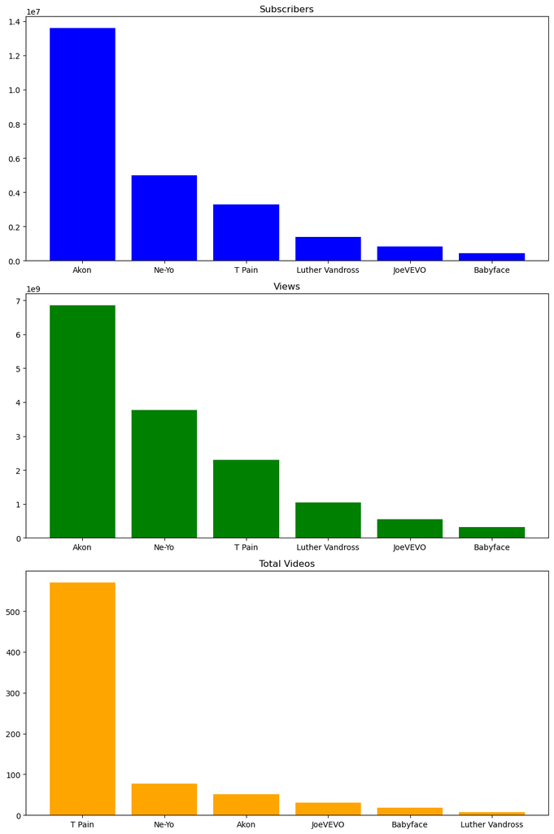

```python
import matplotlib.pyplot as plt

# Sort the DataFrame by 'Subscribers' in descending order
combined_rnb_male_artist_channels_df_subscribers_sorted = combined_rnb_male_artist_channels_df.sort_values(by='Subscribers', ascending=False)

# Plotting Subscribers in descending order
fig, axes = plt.subplots(nrows=3, ncols=1, figsize=(10, 15))

axes[0].bar(combined_rnb_male_artist_channels_df_subscribers_sorted['Channel_name'], combined_rnb_male_artist_channels_df_subscribers_sorted['Subscribers'], color='blue')
axes[0].set_title('Subscribers')

# Sort the DataFrame by 'Views' in descendcombined_real_estate_channels_dfing order
combined_rnb_male_artist_channels_df_views_sorted = combined_rnb_male_artist_channels_df.sort_values(by='Views', ascending=False)

# Plotting Views in descending order
axes[1].bar(combined_rnb_male_artist_channels_df_views_sorted['Channel_name'], combined_rnb_male_artist_channels_df_views_sorted['Views'], color='green')
axes[1].set_title('Views')

# Sort the DataFrame by 'Total_videos' in descending order
combined_rnb_male_artist_channels_df_total_videos_sorted = combined_rnb_male_artist_channels_df.sort_values(by='Total_videos', ascending=False)

# Plotting Total Videos in descending order
axes[2].bar(combined_rnb_male_artist_channels_df_total_videos_sorted['Channel_name'], combined_rnb_male_artist_channels_df_total_videos_sorted['Total_videos'], color='orange')
axes[2].set_title('Total Videos')

# Adjust layout for better visibility
plt.tight_layout()

# Show the plot
plt.show()
```